# Lab2-checkpoint-4

Francinaldo

26 de abril de 2018

# Laboratório 2 - Checkpoint 4

## Descrição da tafera

Utilizando os dados fornecidos pela Wikimedia Discovery criar um **relatório reproduzível*** respondendo as seguintes perguntas:

**1.** Qual é a nossa taxa de cliques geral diária? Como isso varia entre os grupos? **2.** Quais resultados as pessoas tendem a tentar primeiro? Como isso muda no dia-a-dia? **3.** Qual é a nossa taxa diária de resultados zero no geral? Como isso varia entre os grupos? **4.** A duração da sessão é aproximadamente o tempo entre o primeiro e o último evento de uma sessão. Escolha uma variável do conjunto de dados e descreva sua relação com o tamanho da sessão. Visualize o relacionamento.

**5.** Resumir as descobertas em um resumo executivo e postar no RPubs.

## Dados

O conjunto de dados vem de um [esquema de rastreamento](https://meta.wikimedia.org/wiki/Schema:TestSearchSatisfaction2) que foi usado para avaliar a satisfação do usuários. Esse esquema contém as seguintes variáveis

| Variável | Valor | Descrição |
| --- | --- | --- |
| uuid | string | Identificador universalmente exclusivo (UUID) para tratamento de eventos de backend. |
| timestamp | integer | data e hora (UTC) do evento, formatadas como YYYYMMDDhhmmss. |
| session_id | string | Um ID exclusivo que identifica sessões individuais. |
| group | string | A label (“a” or “b”). |
| action | string | Identifica em qual o evento foi criado. Ver abaixo. |
| checkin | integer | Por quantos segundos a página foi aberta. |
| page_id | string | Um identificador exclusivo para correlacionar visitas de páginas e check-ins. |
| n_results | integer | Número de ocorrências retornadas ao usuário. Exibido apenas para eventos searchResultPage. |
| result_position | integer | A posição do link da página visitada na página de resultados do mecanismo de pesquisa (SERP). |

Possíveis valores para o campo de ação de um evento:

- **searchResultPage** : quando uma nova pesquisa é executada e o usuário é mostrado em uma SERP.
- **visitPage** : quando o usuário clica em um link nos resultados.
- **checkin** : quando o usuário permanece na página por um período de tempo previamente especificado.

## Exemplo de uma sessão

| uuid | timestamp | session_id | group | action | checkin | page_id | n_results | result_position |
| --- | --- | --- | --- | --- | --- | --- | --- | --- |
| 4f699f344515554a9371fe4ecb5b9ebc | 20160305195246 | 001e61b5477f5efc | b | searchResultPage | NA | 1b341d0ab80eb77e | 7 | NA |
| 759d1dc9966353c2a36846a61125f286 | 20160305195302 | 001e61b5477f5efc | b | visitPage | NA | 5a6a1f75124cbf03 | NA | 1 |
| 77efd5a00a5053c4a713fbe5a48dbac4 | 20160305195312 | 001e61b5477f5efc | b | checkin | 10 | 5a6a1f75124cbf03 | NA | 1 |
| 42420284ad895ec4bcb1f000b949dd5e | 20160305195322 | 001e61b5477f5efc | b | checkin | 20 | 5a6a1f75124cbf03 | NA | 1 |
| 8ffd82c27a355a56882b5860993bd308 | 20160305195332 | 001e61b5477f5efc | b | checkin | 30 | 5a6a1f75124cbf03 | NA | 1 |
| 2988d11968b25b29add3a851bec2fe02 | 20160305195342 | 001e61b5477f5efc | b | checkin | 40 | 5a6a1f75124cbf03 | NA | 1 |

A consulta da pesquisa deste usuário retornou 7 resultados, eles clicaram no primeiro resultado e permaneceram na página entre 40 e 50 segundos. (O próximo check-in teria acontecido aos 50 segundos).

## Iniciando a análise exploratória

### Carregando as bibliotecas necessárias à execução da tarefa

```r
library(tidyverse)
library(here)
library(lubridate)
theme_set(theme_bw())
```

### Importando os dados

```r
buscas = read_csv(here::here("data/search_data.csv"))
buscas = buscas %>%
    group_by(session_id) %>%
    arrange(session_start_timestamp) %>%
    mutate(search_index = cumsum(results), # contador de buscas na sessão.
    date = as_date(ymd_hms(session_start_timestamp))) %>%
    ungroup()
```

##### Perqunta 1

1. Qual é a nossa taxa de cliques geral diária? Como isso varia entre os grupos?

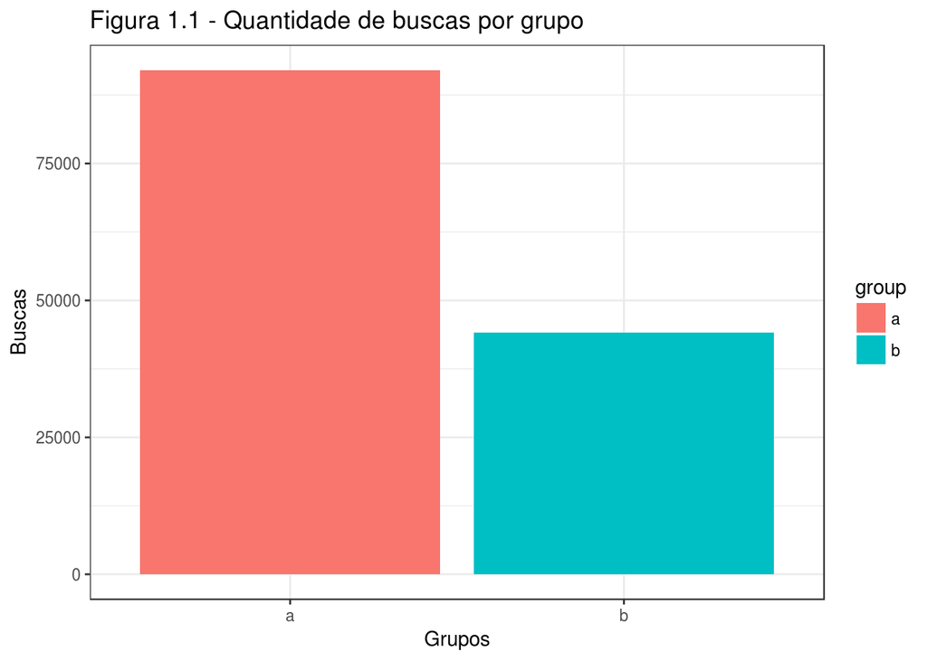

```r
buscas %>%
    group_by(group) %>%
    summarise(n = n()) %>%
    ggplot(aes(x = group, y = n, fill = group)) +
    geom_col() +
    ggtitle("Figura 1.1 - Quantidade de buscas por grupo") +
    labs(x="Grupos",y="Buscas")
```

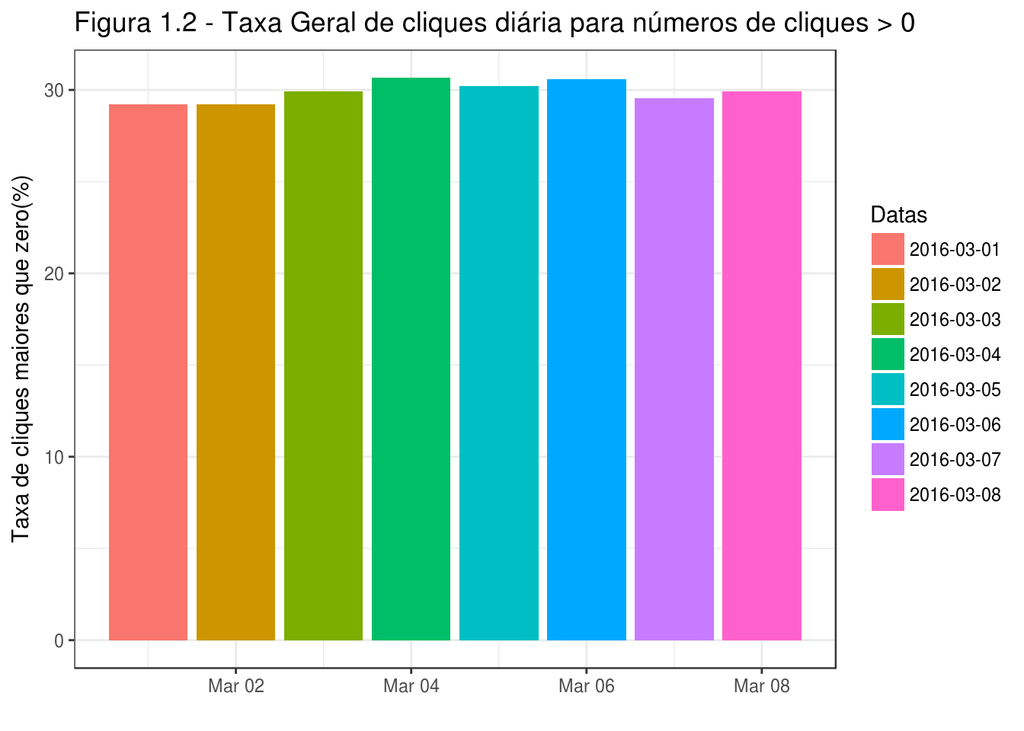

```r
txClik <- buscas %>%
  filter(results >= 1, na.exclude(results)) %>%
  group_by(date, num_clicks) %>%
  summarise(n = n()) %>%
  mutate(txClik = n / sum(n) * 100)

txClik %>%
  filter(num_clicks > 0) %>%
  ggplot(aes(x = date, y = txClik, fill = cut(date, breaks = 8))) +
  geom_col() +
  ggtitle("Figura 1.2 - Taxa Geral de cliques diária para números de cliques > 0") +
  labs(x = "", y = "Taxa de cliques maiores que zero(%)", fill = "Datas")
```

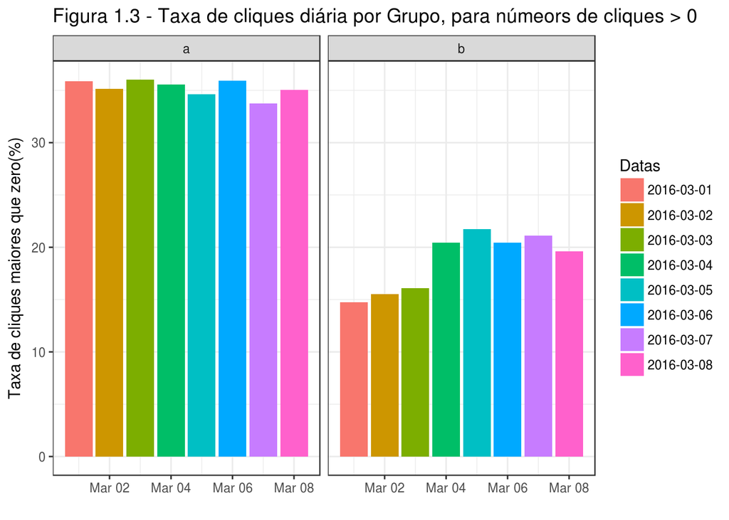

[output not shown]

```r
GtxClik <- buscas %>%
  filter(results >= 1, na.exclude(results)) %>%
  group_by(group, date, num_clicks) %>%
  summarise(n = n()) %>%
  mutate(GtxClik = n / sum(n) * 100)

GtxClik %>%
  filter(num_clicks > 0) %>%
  ggplot(aes(x = date, y = GtxClik, fill = cut(date, breaks = 8))) +
  geom_col() +
  facet_wrap(~group) +
  ggtitle("Figura 1.3 - Taxa de cliques diária por Grupo, para númeors de cliques > 0") +
  labs(x = "", y = "Taxa de cliques maiores que zero(%)", fill = "Datas")
```

##### Pergunta 2

2. Quais resultados as pessoas tendem a tentar primeiro? Como isso muda no dia-a-dia?

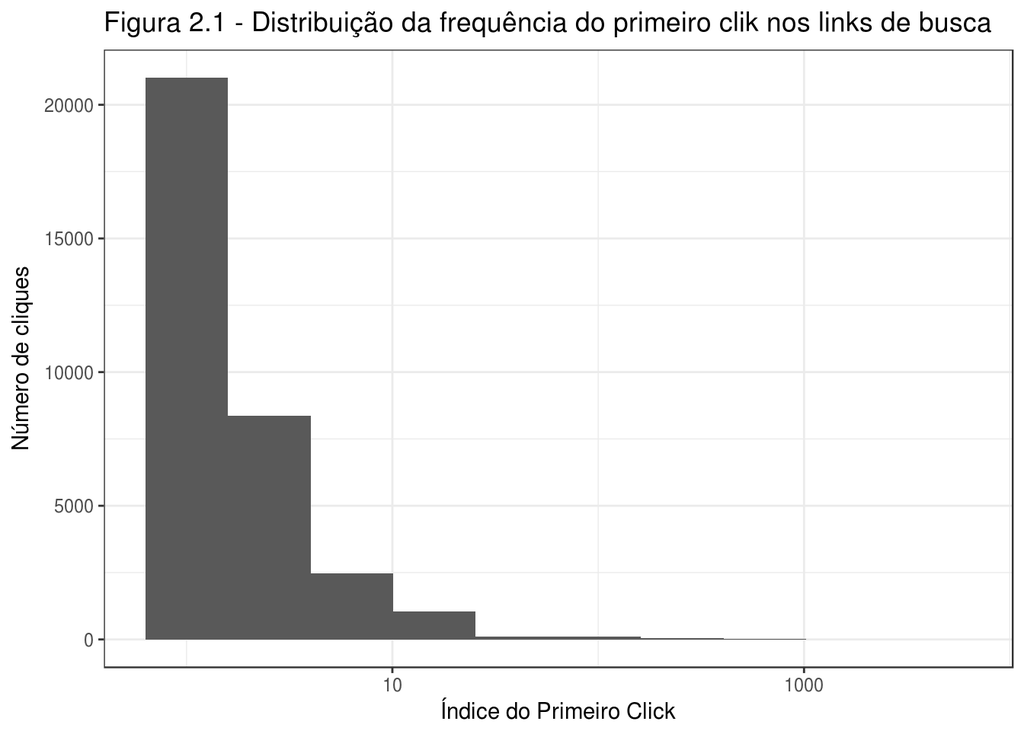

```r
buscas %>%
  na.omit(first_click) %>%
  ggplot(aes(x = first_click)) +
  geom_histogram(bins = 10) +
  scale_x_log10() +
  ggtitle("Figura 2.1 - Distribuição da frequência do primeiro clik nos links de busca") +
  labs(x = "Índice do Primeiro Click",y = "Número de cliques")
```

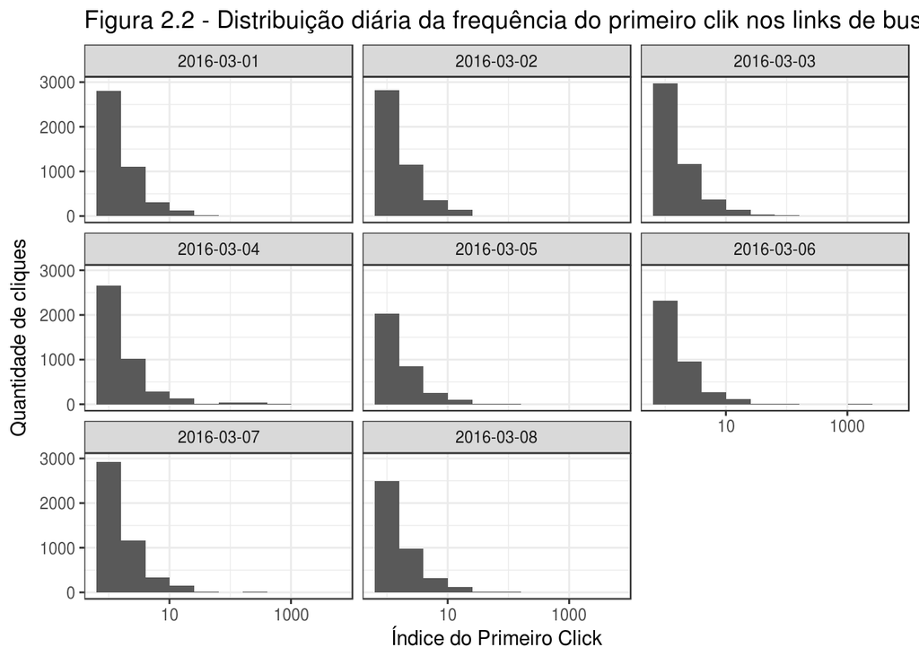

```
  Da Figura 2.1 pode-se verificar que as pessoas tendem a clicar nos primeiros resultados. No dia-a-dia, Figura 2.2, verifica-se o mesmo comportamento geral, os primeiros resultados são os mais clicados.
```

```r
buscas %>%
  na.omit(first_click) %>%
  ggplot(aes(x = first_click)) +
  geom_histogram(bins = 10) +
  scale_x_log10() +
  facet_wrap(~ date) +
  ggtitle("Figura 2.2 - Distribuição diária da frequência do primeiro clik nos links de busca") +
  labs(x = "Índice do Primeiro Click",y = "Quantidade de cliques")
```

##### Pergunta 3

3. Qual é a nossa taxa diária de resultados zero no geral? Como isso varia entre os grupos?

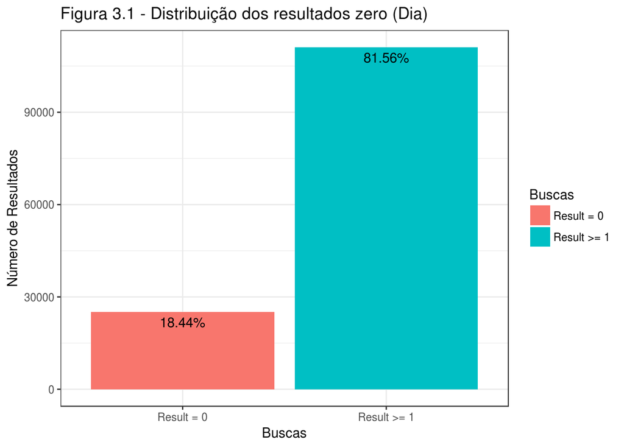

```r
buscas %>%
    mutate(resultados = ifelse(results > 0, "Result >= 1", "Result = 0")) %>%
    count(resultados) %>%
    ggplot(aes(x = resultados, y = n , fill = resultados)) +
    geom_col() +
    geom_text(aes(label=sprintf("%0.2f%%",(n/nrow(buscas)) * 100)), vjust=1.5 , hjust=0.5) +
    ggtitle("Figura 3.1 - Distribuição dos resultados zero (Dia)") +
    labs(x = "Buscas",y = "Número de Resultados", fill = "Buscas")
```

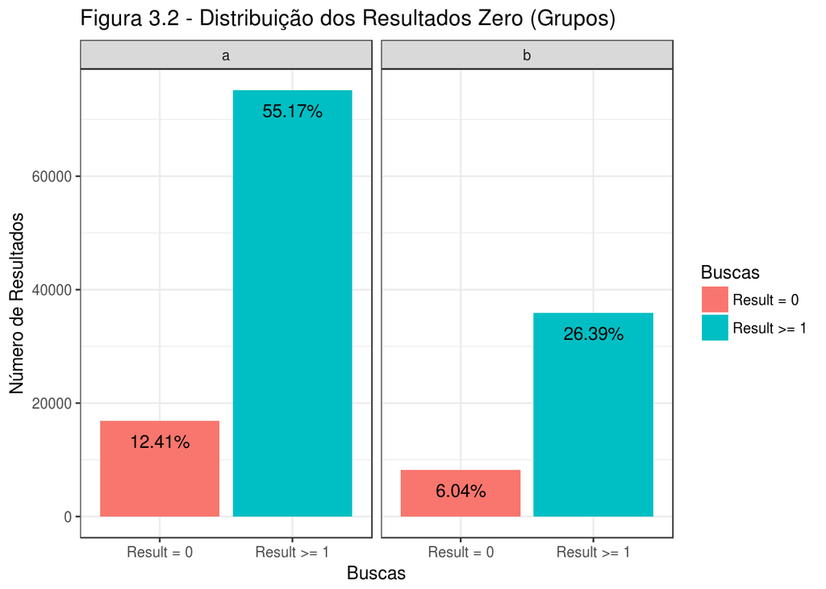

```r
buscas %>%
    group_by(group) %>%
    mutate(resultados = ifelse(results > 0, "Result >= 1", "Result = 0")) %>%
    count(resultados) %>%
    ggplot(aes(x = resultados, y = n , fill = resultados)) +
    geom_col() +
    facet_wrap(~group) +
    geom_text(aes(label=sprintf("%0.2f%%",(n/nrow(buscas)) * 100)), vjust=2 , hjust=0.5) +
    ggtitle("Figura 3.2 - Distribuição dos Resultados Zero (Grupos)") +
    labs(x = "Buscas",y = "Número de Resultados", fill = "Buscas")
```

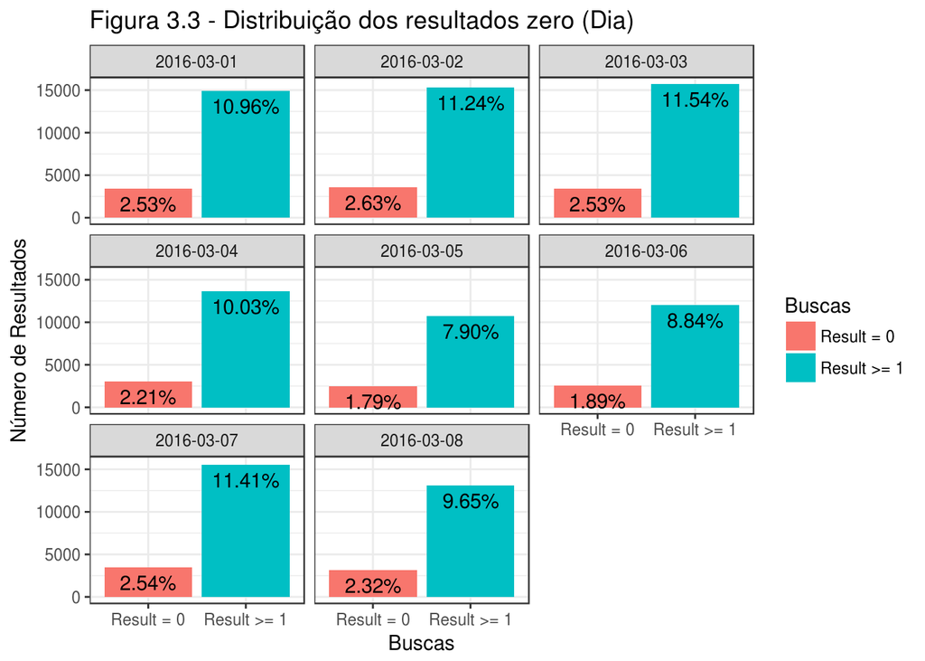

```
  Conforme pode ser verificado na Figura 3.1, a taxa geral de resultados zero é de aproximadamente 18% para os dois grupos.
  A taxa de resultados zero por grupo, Figura 3.2, mantém a mesma proporção.
```

```r
buscas %>%
    group_by(date)%>%
    mutate(resultados = ifelse(results > 0, "Result >= 1", "Result = 0")) %>%
    count(resultados) %>%
    ggplot(aes(x = resultados, y = n , fill = resultados)) +
    geom_col() +
    facet_wrap(~ date) +
    geom_text(aes(label=sprintf("%0.2f%%",(n/nrow(buscas)) * 100)), vjust=1.5 , hjust=0.5) +
    ggtitle("Figura 3.3 - Distribuição dos resultados zero (Dia)") +
    labs(x = "Buscas",y = "Número de Resultados", fill = "Buscas")
```

##### Pergunta 4

4. A duração da sessão é aproximadamente o tempo entre o primeiro e o último evento de uma sessão. Escolha uma variável do conjunto de dados e descreva sua relação com o tamanho da sessão. Visualize o relacionamento.

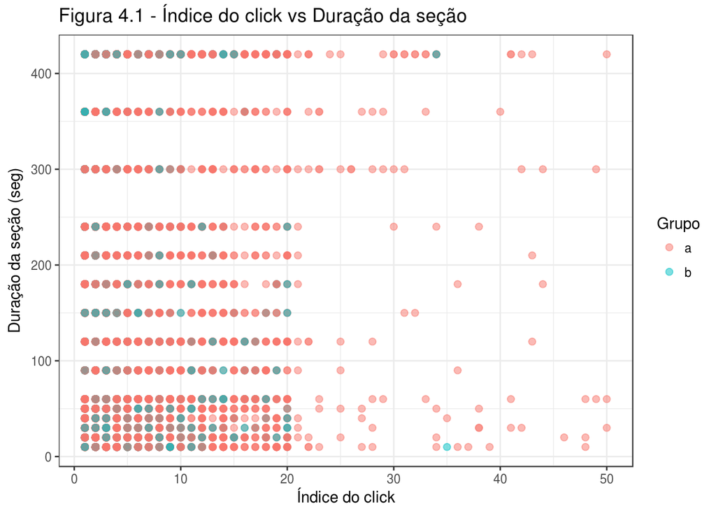

[output not shown]

```r
buscas %>%
    filter(session_time != -Inf, first_click <= 50) %>%
    ggplot(aes(x = first_click, y = session_time, color=group)) +
    geom_point(alpha = .5, size = 2) +
    ggtitle("Figura 4.1 - Índice do click vs Duração da seção") +
    labs(x = "Índice do click",y = "Duração da seção (seg)", color = "Grupo")
```